# Part II - Ford GoBike Data Exploration

## by Kristina Klimenchuk

## Investigation Overview

The main goal is to find demographic values of the data set and investigate how users use the service.

## Dataset Overview

Data has 183412 rows and 16 columns. Data includes information about users, bike stations, duration of the rides. Information about users contains: `user type (customer or subscriber)`, `birth year`, and `gender`. The main focus on user-related features: `user_type`, `member_birth_year`(age), and `member_gender`. Features `duration_sec` will help investigate users' behavior.

## Distribution of ride durations

Since the distribution is skewed, I put the x-axis on a log scale to make the histogram more informative. As a result, the median ride is 511 seconds, and the average ride is 704 seconds. Durations of rides take on a vast range of values, from 61 seconds at the lowest to 84548 seconds at the highest.

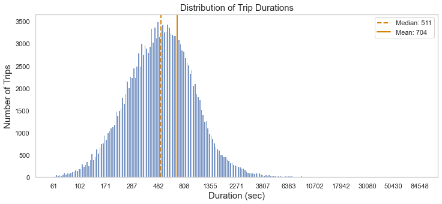

## The ratio of the users' type by gender

The major part of each gender consists of the "Subscriber" user type. For **male `"Subscriber"` type equals 91%**, for females 89% and other 88%. Also, the plot shows that males make up most of the dataset, which is **75% of all users.**

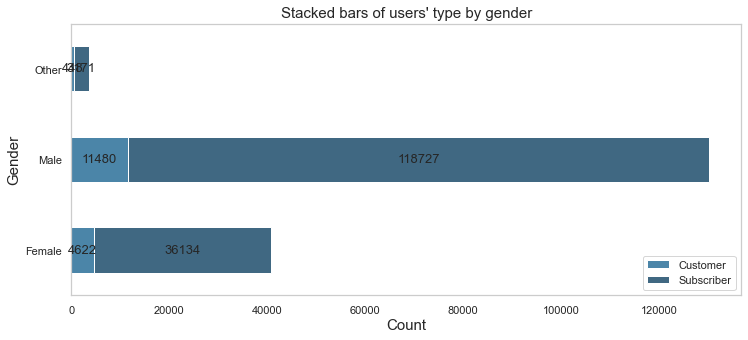

## Distribution of average duration rides by users' age

Users in 30 years made the most significant number of long rides.

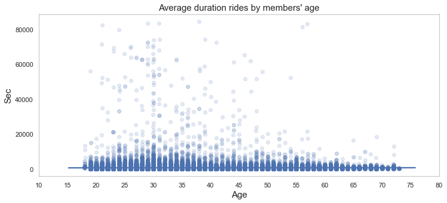

## The average duration of ride for each day of week by users' type

The line plot demonstrates that the average ride duration among "Subscribers" does not change much depending on the days of the week. At the same time, the average ride duration among "Customers" rises sharply on weekends. The **"Customer"** average ride duration is **1310 seconds**, and the average **"Subscriber"** duration of ride equals **640 seconds.**

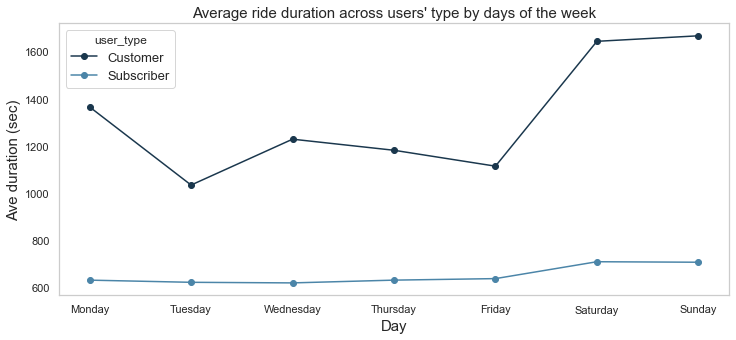